```python
# Import libraries
import numpy as np
import pandas as pd
import datetime
import matplotlib.pyplot as plt
%matplotlib inline
import calendar
```

# Hypothesis

I believe that there is a correlation between the number of murders and the temperature in the city of Dallas, Texas.

## Reading the data

First we'll go ahead and read the Data, and see what it looks like

```python
weatherDF = pd.read_csv("Weather_avgs.csv")
murdersDF = pd.read_csv("Dallas_murders.csv")
```

```python
weatherDF.head()
```

|  | Year | Jan | Feb | Mar | Apr | May | Jun | Jul | Aug | Sep | Oct | Nov | Dec | Total |
| --- | --- | --- | --- | --- | --- | --- | --- | --- | --- | --- | --- | --- | --- | --- |
| 0 | 2019 | 45.8 | 50.2 | 55.0 | 66.0 | 73.4 | 79.9 | 84.6 | 87.4 | NaN | NaN | NaN | NaN | NaN |
| 1 | 2018 | 45.8 | 51.1 | 63.3 | 61.6 | 79.0 | 85.7 | 88.8 | 85.2 | 78.1 | 66.2 | 52.5 | 48.4 | 67.1 |
| 2 | 2017 | 51.2 | 60.6 | 65.7 | 69.3 | 75.4 | 82.5 | 86.6 | 84.4 | 80.6 | 69.6 | 62.4 | 49.7 | 69.8 |
| 3 | 2016 | 47.0 | 55.2 | 61.2 | 68.1 | 72.5 | 84.0 | 87.4 | 85.8 | 81.5 | 74.1 | 63.5 | 49.7 | 69.2 |
| 4 | 2015 | 44.5 | 45.7 | 56.1 | 65.8 | 70.9 | 82.1 | 87.1 | 87.3 | 82.7 | 71.2 | 58.7 | 53.7 | 67.2 |

```python
murdersDF.head()
```

|  | Incident Number w/year | Date1 of Occurrence | Council District | Offense Status | Division | Weapon Used | Gang Related Offense | Incident Address | Year of Incident | Service Number ID | ... | NIBRS Code | NIBRS Group | NIBRS Type | Update Date | X Coordinate | Y Cordinate | Zip Code | City | State | Location1 |
| --- | --- | --- | --- | --- | --- | --- | --- | --- | --- | --- | --- | --- | --- | --- | --- | --- | --- | --- | --- | --- | --- |
| 0 | 198479-2019 | 09/29/2019 | NaN | Open | SOUTHEAST | Handgun | UNK | 3122 MCDERMOTT AVE | 2019 | 198479-2019-01 | ... | 09A | A | Coded | 2019-09-29 20:18:58.0000000 | 2.504240e+06 | 6.966139e+06 | 75215.0 | DALLAS | TX | 3122 MCDERMOTT AVE\nDALLAS, TX 75215\n(32.7665... |
| 1 | 198164-2019 | 09/29/2019 | NaN | Open | SouthWest | Handgun | UNK | 6910 S COCKRELL HILL RD | 2019 | 198164-2019-01 | ... | 09A | A | Coded | 2019-09-29 11:45:25.0000000 | NaN | NaN | 75236.0 | DALLAS | TX | 6910 S COCKRELL HILL RD\nDALLAS, TX 75236\n(32... |
| 2 | 195748-2019 | 09/26/2019 | D2 | Clear by Arrest | CENTRAL | Handgun | UNK | 5409 PHILIP AVE | 2019 | 195748-2019-01 | ... | 09A | A | Coded | 2019-09-27 09:55:34.0000000 | 2.506134e+06 | 6.975935e+06 | 75223.0 | DALLAS | TX | 5409 PHILIP AVE\nDALLAS, TX 75223\n(32.792821,... |
| 3 | 195140-2019 | 09/25/2019 | D7 | Clear by Arrest | SOUTHEAST | Other/Unknown Gun | UNK | 5209 S LAMAR ST | 2019 | 195140-2019-01 | ... | 09A | A | Coded | 2019-09-29 21:02:50.0000000 | 2.503313e+06 | 6.958015e+06 | 75215.0 | DALLAS | TX | 5209 S LAMAR ST\nDALLAS, TX 75215\n(32.744189,... |
| 4 | 194775-2019 | 09/24/2019 | D8 | Open | SOUTHEAST | NaN | NaN | 1700 EDD RD | 2019 | 194775-2019-01 | ... | 999 | D | Not Coded | 2019-09-26 11:32:09.0000000 | 2.551665e+06 | 6.936549e+06 | 75253.0 | DALLAS | TX | 1700 EDD RD\nDALLAS, TX 75253\n(32.682485, -96... |

5 rows × 100 columns

# Data Engineering

We can see that we can join both datasets by the date, but there are 3 present problems.  
1.) The datasets are grouped by different values. Weather dataset has monthly values, and murder dataset has daily values.  
2.) The datasets have different date ranges  
3.) We have to un-pivot the weather dataset in order to be able to join with the murder dataset

### Group discrepencies and Date Ranges

We'll begin by solving the first two problems by grouping the murder dataset to a monthly view. Then we'll set the date range to only be after 2014. We'll calculate the total number of murders per month

```python
murdersDF['Date1 of Occurrence'] = pd.to_datetime(murdersDF['Date1 of Occurrence'])
murdersDF = murdersDF.loc[murdersDF['Year of Incident'] > 2014]
murdersDF = murdersDF.loc[murdersDF['Date1 of Occurrence'].dt.year > 2014]
murdersDF = murdersDF['Date1 of Occurrence'].groupby([murdersDF['Date1 of Occurrence'].dt.year.rename('year'),
                                                 murdersDF['Date1 of Occurrence'].dt.month.rename('month')]).agg({'count'})
```

```
MultiIndex([(2015,  1),
            (2015,  2),
            (2015,  3),
            (2015,  4),
            (2015,  5),
            (2015,  6),
            (2015,  7),
            (2015,  8),
            (2015,  9),
            (2015, 10),
            (2015, 11),
            (2015, 12),
            (2016,  1),
            (2016,  2),
            (2016,  3),
            (2016,  4),
            (2016,  5),
            (2016,  6),
            (2016,  7),
            (2016,  8),
            (2016,  9),
            (2016, 10),
            (2016, 11),
            (2016, 12),
            (2017,  1),
            (2017,  2),
            (2017,  3),
            (2017,  4),
            (2017,  5),
            (2017,  6),
            (2017,  7),
            (2017,  8),
            (2017,  9),
            (2017, 10),
            (2017, 11),
            (2017, 12),
            (2018,  1),
            (2018,  2),
            (2018,  3),
            (2018,  4),
            (2018,  5),
            (2018,  6),
            (2018,  7),
            (2018,  8),
            (2018,  9),
            (2018, 10),
            (2018, 11),
            (2018, 12),
            (2019,  1),
            (2019,  2),
            (2019,  3),
            (2019,  4),
            (2019,  5),
            (2019,  6),
            (2019,  7),
            (2019,  8),
            (2019,  9)],
           names=['year', 'month'])
```

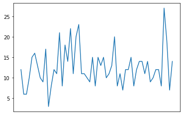

```python
print(murdersDF.index)

# Concatenate the multi index into 1 YYYY-MM column
l_tuples = list(murdersDF.index._tuples)
newTuples = [(str(t[0]) + "-" + str(t[1])) for t in l_tuples]
murdersDF['yr_mnth'] = newTuples

# Reset the index
murdersDF = newDF.reset_index()

# Drop the last record
murdersDF.drop(newDF_t.tail(1).index, inplace = True)
plt.plot(murdersDF['yr_mnth'], murdersDF['count'])

# Remove x ticks for simplicity
plt.tick_params(
    axis='x',
    which='both',
    bottom=False,
    top=False,
    labelbottom=False)
plt.show()
```

# Weather Dataset Date Ranges

```python
weatherDF = weatherDF.sort_values(by='Year', ascending = 'True')
weatherDF = weatherDF.loc[weatherDF.Year > 2014]

weatherDF = weatherDF.drop(columns = ['Total'], axis = 1)
weatherDF_tmp = weatherDF.drop(columns = ['Year'], axis = 1)
weatherDF_tmp.head()
```

|  | Jan | Feb | Mar | Apr | May | Jun | Jul | Aug | Sep | Oct | Nov | Dec |
| --- | --- | --- | --- | --- | --- | --- | --- | --- | --- | --- | --- | --- |
| 4 | 44.5 | 45.7 | 56.1 | 65.8 | 70.9 | 82.1 | 87.1 | 87.3 | 82.7 | 71.2 | 58.7 | 53.7 |
| 3 | 47.0 | 55.2 | 61.2 | 68.1 | 72.5 | 84.0 | 87.4 | 85.8 | 81.5 | 74.1 | 63.5 | 49.7 |
| 2 | 51.2 | 60.6 | 65.7 | 69.3 | 75.4 | 82.5 | 86.6 | 84.4 | 80.6 | 69.6 | 62.4 | 49.7 |
| 1 | 45.8 | 51.1 | 63.3 | 61.6 | 79.0 | 85.7 | 88.8 | 85.2 | 78.1 | 66.2 | 52.5 | 48.4 |
| 0 | 45.8 | 50.2 | 55.0 | 66.0 | 73.4 | 79.9 | 84.6 | 87.4 | NaN | NaN | NaN | NaN |

### Unpivot

Next we unpivot the values so we can match our dataset with the first dataset

```
    temperature
0          44.5
1          45.7
2          56.1
3          65.8
4          70.9
5          82.1
6          87.1
7          87.3
8          82.7
9          71.2
10         58.7
11         53.7
12         47.0
13         55.2
```

[output cut: 42 more lines]

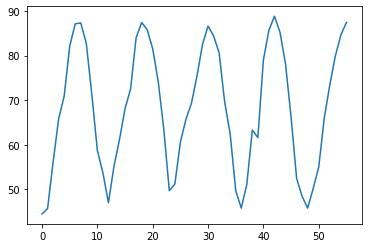

```python
temperatureDF = pd.DataFrame()

# Capture the values into an array
temperatures = weatherDF_tmp.values.reshape(5*12)

# Remove the last 4 months as they do not appear on the murder dataset
temperatures = temperatures[:-4]

temperatureDF['temperature'] = temperatures
print(temperatureDF)
plt.plot(range(0, len(temperatureDF.index)), temperatureDF['temperature'])
```

## Joining datasets

Now that both datasets are aligned by the same year-month. We can append the monthly temperatures to the monthly murders dataset

```python
murdersDF['temperature'] = temperatures
print(newDF_t)
```

```
    year  month  count  yr_mnth  temperature
0   2015      1     12   2015-1         44.5
1   2015      2      6   2015-2         45.7
2   2015      3      6   2015-3         56.1
3   2015      4     10   2015-4         65.8
4   2015      5     15   2015-5         70.9
5   2015      6     16   2015-6         82.1
6   2015      7     13   2015-7         87.1
7   2015      8     10   2015-8         87.3
8   2015      9      9   2015-9         82.7
9   2015     10     17  2015-10         71.2
10  2015     11      3  2015-11         58.7
11  2015     12      8  2015-12         53.7
12  2016      1     12   2016-1         47.0
13  2016      2     11   2016-2         55.2
```

[output cut: 42 more lines]

# Correlation

## Scatter Plot

We can begin py plotting both variables in a scatter plot, to try to visualize a correlation

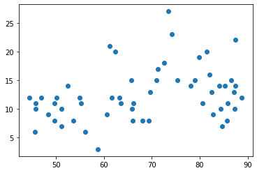

```python
plt.scatter(murdersDF['temperature'], murdersDF['count'])
```

## Correlation Calculation

Finally, we can calculate the correlation between the variables

```python
correlation = murdersDF['count'].corr(murdersDF['temperature'])

print(correlation)
```

```
0.32775193981308437
```

# Linear Regression

We can then visualize the correlation by fitting a linear regression, and plotting it along with the scatter plot

```python
from sklearn import datasets, linear_model
from scipy import stats
from sklearn.metrics import mean_squared_error, r2_score
```

[output not shown]

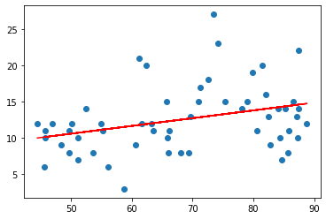

```python
slope, intercept, r_value, p_value, std_err = stats.linregress(murdersDF['temperature'],murdersDF['count'])
print(r_value)
plt.scatter(murdersDF['temperature'], murdersDF['count'])
plt.plot(murdersDF['temperature'], intercept + slope*murdersDF['temperature'], 'r', label='fitted line')
```

# Conclusion

We can conclude that there exists a correlation, 0.32, between the two variables, be it a small one.